# Analyse des données de googlesheet

Yves Amevoin

12/04/2020

L’objectif de ce fichier est de présenter les analyses relatives aux données d’un formulaire google. L’enquête a été effectuée par Elvis. Elle consiste à recueillir des informations sur une base qui constituerait potentiellement des futurs consommateurs de contenu vidéo. Vous pouvez télécharger le fichier Rmarkdown qui a servi à générer ce html en haut à droite.

Les analyses ont été effectuées sous [R](https://www.r-project.org/) en utilisant [Rstudio](https://rstudio.com/).

## Préliminaires (Vous pouvez sauter)

### Package et fonctions nécessaires

Le chunck suivant charge les packages qui ont été utilisées dans mon analyse. Vous devriez les installer si vous ne les avez pas. Mais j’écris un petit code qui va se charger d’installer les packages quand ils sont non présents.

```r
knitr::opts_chunk$set(fig.path = "./figures/")

required_packages <- c("dplyr", "tibble",  "tidyr", "purrr", "ggplot2",
                       "scales", "magrittr", "openxlsx", "gt",
                       "googledrive", "googlesheets4", "FactoMineR")


pkg_to_inst <- setdiff(required_packages, installed.packages()[,1])

if(length(pkg_to_inst)) install.packages(pkg_to_inst)

#chargement des packages
lapply(required_packages, library, character.only = TRUE)
#may be you will need also to install ggthemr from github by running
# devtools::install_github('cttobin/ggthemr')
#(not necessary though)
library("ggthemr")

ggthemr("dust")
```

### Les objets que j’utilise

Je définis ici quelques objets que je vais utiliser de par la suite dans mon travail. C’est en particulier la liste des thèmes, les expressions régulières utilisées pour virer des caractères et aussi quelques redéfinitions de fonctions pour éviter les conflits. Il faut aussi ajouter que je ne suis pas très friand de longs noms pour les variables, vous pouvez comprendre les noms de variables comme une abréviation anglophone (en enlevant souvent les voyelles).

```r
#regular expression used to filter out every words in the themes exept the
#theme number. I filtered out also the i7, 2g and usb3 things in the writing.

reg_thm <- "[A-z[:punct:]]|(i\\d?)|(\\d?g)|(usb\\s?\\d?)"

#list of themes of the questionnaire
themes_names <- c(
  'Thème 1 : Iphone vs Android phone.',
  'Thème 2 : Comment fonctionne la caméra de votre Smartphone.',
  'Thème 3 : Caméra un Smartphone vs appareil photo professionnel',
  'Thème 4 : Les TV LCD, LED, Plasma, OLED',
  'Thème 5 : les GAFAM et la question des données sur notre vie privée',
  'Thème 6 : Le CLOUD',
  'Thème 7 : Les processeurs Intel, Core i3, Core i5, Core i7, Core i9',
  'Thème 8 : Les malwares et virus, le piratage et les hackeurs.',
  'Thème 9 : INTERNET, comment ça fonctionne exactement?',
  'Thème 10 : NETFLIX, comment ça fonctionne exactement?',
  'Thème 11 : Différence entre ports USB 2, USB 3 et USB type C.',
  'Thème 12 : Les réseaux téléphoniques : 2G, 3G, 4G, 5G.',
  'Thème 13 : Windows vs Linux vs Mac OS',
  'Thème 14 : Whatsapp, Facebook, Instagram, Youtube: Business model',
  'Thème 15 : Le téléphone portable, les appels téléphoniques')

#values of works category
values <- c("administration",  "artisanat et immobilier",
            "communication et marketing",  "commerce, economie et comptabilite",
            "litterature et droit", "autres", "scientifique", "it")

#update if you decide to split categories or to add something new
names(values) <- c("adm_words", "art_words", "com_words", "eco_words",
                   "lit_words", "oth_words", "sci_words", "it_words")


# Breaks used in graph plots for percentages.

perbreaks <- seq(0, 1, by = 0.025)
#colors for those breaks. I will put the 25%, 30%, 50% and 60% in red, the
#others in blue
perc_colors <- rep("blue", length(perbreaks))
perc_colors[c(11, 13, 21, 25)] <- "red"


#I dont want to boder myself with future errors on filter and select due
#to conflicts. So I redefine them
filt <- dplyr::filter
selt <- dplyr::select

#Theme I will use
ggthemr("dust")
```

### Les fonctions que j’utilise

Les traitements reposent en général sur des fonctions que je vais utiliser. Il y a toujours un point “dot” séparant les deux parties des noms de mes fonctions. Cela permet de comprendre à quoi correspond mes fonctions. Il ne s’agit pas d’une méthode d’un objet, c’est ma façon de noter les noms de fonctions.

```r
#-- Number of missing value within a vector (vctr)
nb.nas <- function(vctr) sum(is.na(vctr))

# function to repeat a word a number of times, this number of times
# is the length of another vector
rep.lgth <- function(wrd, vctr) rep(wrd, length(vctr))

#-- convert a character vector to asciilower case.
#-- apply a regular expression to the vector (default is the reg_thm created)
#-- and deal with empty spaces after
asc.low <- function(vctr, regex = reg_thm){
  vctr <- iconv(vctr, from = "UTF-8", to = "ASCII//TRANSLIT") %>% tolower()
  vctr <- gsub(regex, " ", vctr)
  gsub("\\s+", " ", trimws(vctr))
}

#-- clean the other themes vector by removing all the no and so on.
oth.fct <- function(vctr){
  vctr <- asc.low(vctr, "^non?\\.?$|^ou?o?i?\\.?|^tout?s?$")
  gsub("^\\s+$", NA, vctr)
}

#-- Take a data.frame
#-- Compute for a variable the number of characters for each individuals or a key
#-- For individual having the same key, retain only the line corresponding to
#   the longest number of characters for the given variable
# idvar is the key var, lgvar is the variable where the nchar is computed.
rmv.small <- function(a_dt, idvar, lgvar){

  idvars <- enquo(idvar)
  lgvars <- enquo(lgvar)

  ag_dt <- a_dt %>%  mutate(lgth = nchar(!!lgvars))

  gp_dt <- ag_dt %>%
    group_by(!!idvars) %>%
    summarize(mxlgth = max(lgth))

  ag_dt <- ag_dt %>% left_join(gp_dt, by = quo_name(idvars))

  ag_dt %>%
   filt(lgth == mxlgth | is.na(lgth)) %>%
   selt(-c(lgth, mxlgth))
}

#Take a data.frame
# For each element of a vector, subset the data.frame for rows of
# a given variable corresponding to the vector
# Take for this subset data.frame first element of another vector (only one line)
# Bind all the first elements together for each element of a vector.

get.fst.hr <- function(a_dt, var, hvar, vctr){
  var <- enquo(var)
  hvar <- enquo(hvar)
  #void data.frame
  sub_dt <- data.frame()

  for(i in seq_along(vctr)){
    #subseting and sorting
    don <- a_dt %>%
      filt(!!var %in% vctr[i]) %>%
      arrange(desc(!!hvar)) %>%
      #select the first line
      slice(1)
    #bind with the void data.frame
    sub_dt <- bind_rows(sub_dt, don)
  }
  #return every thing
  sub_dt
}

#
#

#-- Take a vector
#-- Dans dicothomize it for a given length (default is 14)
# Ex (if length = 5) : c(3, 2, 5) --> (0, 1, 1, 0, 1)
# The Ones are on the position of in the input vectors, and position not
# found correspond to zeros
dthm.vtr <- function(vctr, lgth = 14){
  empty <- rep(0, lgth)
  empty[which(1:lgth %in% vctr)] <- 1
  empty
}

#-Take a data.frame
#- Select some variables
#- split them on spaces, convert them to numeric and dicotomize them using
#  previous function

dthm.dt <- function(a_dt, var, l = 14, split = "\\s"){
  vars <- enquo(var)

  thm_splt <- a_dt %>% selt(!!vars) %>% unlist()
  # splitting
  strsplit(thm_splt, split = split) %>%
    # converting to numeric
    lapply(as.numeric) %>%
    #sorting
    lapply(sort) %>%
    #dicotomize
    lapply(dthm.vtr, lgth = l) %>%
    #combining everything
    bind_rows() %>%
    t() %>%
    as.data.frame() %>%
    set_colnames(paste("thm", 1:l, sep = ""))
}

# - Take a data frame
# - Select some variables of the dataframe
#- For each variable selected, compute the mean.
#- In my case I will deal with O and 1, so it is the proportion (of themes)
comp.thmprop <- function(a_dt, var){
  var <- enquo(var)

  a_dt %>%
    select(!!var) %>%
    apply(2, mean) %>%
    enframe(name = "themes", value = "perc") %>%
    mutate(themes = gsub("^thm", "Theme ", themes))
}

#- Take a data frame (a_dt)
#- Select some variables of the dataframe (var)
#- Compute the sum of the weighted transformation of those variables
# The weight are obtained by dividing every variable
# by the rowsum of all the variable. (for one individual)

comp.thmpref <- function(a_dt, var){
  var <- enquo(var)

  a_dt %>%
    select(!!var) %>%
    apply(1, function(x) x / sum(x, na.rm = TRUE)) %>%
    apply(1, sum, na.rm = TRUE) %>%
    enframe(name = "themes", value = "wgt")%>%
    mutate(themes = gsub("^thm", "Theme ", themes))
}

# graphic representation function:
```

## Nettoyage de la base de données

### Chargement et doublons

```r
# loading the database. We have twoo options. First one is to download
# the data from google and put it in the current directory.
# second one is to download directly from googledrive using the
# googledrive and googlesheets  packages.

#uncomment the first line if you were unable to download direclty  and
#comment the following line (the line with drive_get).
#Don't forget to put the downloaded data in the current working directory

#dt <- read.xlsx("enquete_elvis_tic.xlsx")

dt <- drive_get("enquete_elvis_tic") %>% sheets_read()
colnames(dt) <- c("hur", "mail", "scr", "thm", "oth_thm",
                  "wrks", "sex", "age", "cntry", "whats")
```

Il faut maintenant que je sépare la base de données en deux parties. Une première partie pour les personnes n’ayant pas de doublon (en utilisant le mail comme une clé) et une seconde partie pour les personnes ayant un doublon (la même personne a rempli plusieurs fois le questionnaire).

```r
#The first think is to filter them out
sgl_dt <- dt %>% add_count(mail) %>% filt(n == 1) %>% selt(-n)
mpl_dt <- dt %>% add_count(mail) %>% filt(n > 1) %>% selt(-n)

#On peut faire un checking pour verifier:
pourc <- (unique(mpl_dt$mail) %>% length()) / (unique(dt$mail) %>% length())
nrow(sgl_dt) + nrow(mpl_dt) == nrow(dt)
```

```
## [1] TRUE
```

Il faut maintenant traiter les doublons. Les doublons représentent 7.62% des observations. Voilà comment en gros je procède au traitement sur la base des doublons:

- J’enlève de la base tous ceux qui ne se sont arrêtés qu’au remplissage du mail. Parfois il y a des personnes qui n’ont rien remplies les fois suivantes après avoir rempli totalement le questionnaire la première fois. Je me contente juste d’enlever ces lignes. Dans certains cas, cela suffit pour n’avoir que une seule entrée pour ces personnes. J’enlève donc les lignes qui n’ont que l’heure et le mail renseignés, ainsi que la variable `scr`(qui vaut 0 pour tout le monde).
- Je traite les thèmes et les autre thèmes. Pour le traitement des thèmes, j’utilise les expressions régulières pour virer tous les labels des thèmes à l’exception du numéro du thème proprement dit. Pour le traitement des autres thèmes, je me limite seulement à enlever les `oui`, `non` et consort qui ont été donnés comme réponse.
- Une fois les thèmes et les autres thèmes traités, je vire les lignes qui se répètent (`distinct`). A cette étape, il ne reste qu’à corriger dans la base des doublons, les individus ayant renseigné correctement et de différentes façons le questionnaire plus d’une fois.
- Une analyse m’a permis de voir que la variable qui changeait régulièrement pour les individus ayant renseigné le questionnaire correctement plus d’une fois est le plus souvent le thème (`thm`) ou les autres thèmes (`othm`). J’ai choisi pour ces individus, leur première entrée du questionnaire (en regardant l’heure à laquelle ces individus ont envoyé le questionnaire).

```r
#first step is to stick to clean and correct the themes, and filter out
#irrelevant lines
mpl_dt <- mpl_dt %>%
  mutate(nb_nas = apply(mpl_dt, 1, nb.nas)) %>%
  #filtering out non answers // all nas on the line, first 3 columns are
  # filled
  filt(nb_nas < (ncol(dt) - 4)) %>%
  #dealing with others // using my functions
  mutate(thm = asc.low(thm)) %>%
  mutate(oth_thm = oth.fct(oth_thm))

#This is where I have my first part (distinct and completely filled more than
#once)
mpl_dt_fst <- mpl_dt %>%
  selt(-c(hur, nb_nas, whats)) %>%
  #removing those unwanted variables before focusing on distinct
  distinct()

# Now I count those duplicated elements and focus on the hour of recording
mails_db <- mpl_dt_fst %>% count(mail) %>% filt(n > 1) %>% with(mail)

#I filtered out those mail from the double count and select only the first
# hour the individual has sent its answer
mpl_dt_sd <- mpl_dt %>%
  get.fst.hr(mail, hur, mails_db) %>%
  selt(-c(hur, nb_nas, whats))


#unique elements (finally)
mpl_dt_tr <- mpl_dt_fst %>% filt(!(mail %in% mails_db)) %>% bind_rows(mpl_dt_sd)

# a checking to be sure everything works fine
nrow(mpl_dt_tr) == (mpl_dt %>% with(mail) %>% unique %>% length)
```

```
## [1] TRUE
```

Une fois que le traitement des doublons a été effectué, la prochaine étape consiste a mettre tout ensemble pour obtenir une nouvelle base de données, cette fois ci sans doublons et relativement propre. On va aussi dicotomiser la variable thèmes, et commencer par préparer la base de données pour de nouvelles analyses.

```r
new_dt <- sgl_dt %>%
  selt(-c(hur, whats)) %>%
  mutate(thm = asc.low(thm), oth_thm = oth.fct(oth_thm)) %>%
  bind_rows(mpl_dt_tr)

# I don't border myself with missing values in the cleared data.frame,
# since they are most of the time non important questions (except the country)

#dicotomization of the theme variable:

# applying the dicotomization on the dataframe of single observations
new_dt <- new_dt %>%
  bind_cols(dthm.dt(new_dt, thm))
```

### Les catégories professionnelles

Le nettoyage des catégories socio-professionnelles est relativement simple. On commence d’abord par se focaliser sur l’ensemble des catégories qui ont été relevées durant l’enquête, et on les regroupe. Cette partie effectue le traitement direct des autres catégories. Il va donc falloir lors d’un rechargement de la base de données, s’assurer que toutes les catégories présentes ont été recensées et affectées à une classe bien précise.

```r
#first, we correct the spelling by removing unecessary stuffs
new_dt <- new_dt %>%
  mutate(wrks = asc.low(wrks, regex = "\\d"))

#We start by taking a look at unique elements of working group
list_wrks <- new_dt %>% with(wrks) %>% unique()
cat(paste(list_wrks, collapse = ". "))
```

```
## scientifique. droit et langue. commerce/gestion/economie. technologie. diplomatie. communication. litteraire/droit/langue. medecine. artisanat. architecture immobilier. para medical. NA. btp. eleve. recherche. stylisme. transport. communication/marketing/journalisme. enseignant. etudiant. engenie…
```

Les catégories sont les suivantes, le premier mot du nom de la catégorie permet de comprendre à quel groupe elle correspond (sci par ex. pour scientifique, etc.). Vous pouvez ajouter un nouvel élément dans la catégorie correspondante (en séparant chaque élément d’une virgule) si vous vous rendez compte qu’il y a de nouvelles catégories qui apparaissent.

```r
sci_words <- c("scientifique", "para medical", "engenierie", "sante",
               "medecine", "bioethique", "recherche", "enseignant")
it_words <- c("technologie")
com_words <- c("communication", "communication/marketing/journalisme")
art_words <- c("artisanat", "btp", "architecture immobilier", "stylisme",
                "transport")
adm_words <- c("technique administrative", "diplomatie", "securite publique")
eco_words <- c("commerce/gestion/economie", "audit et comptabilite")
lit_words <-c("litteraire/droit/langue", "droit et langue")
oth_words <- c("eleve", "etudiant")

# a little check to be sure everything is ok. I think you will have to readjust
# or add some elements to classes if necessary.
categ <- grep("words$", ls(), value = TRUE)
tst_vc <- categ  %>% lapply(function(x) get(x))

names(tst_vc) <- categ


#This should return TRUE if not you can update.
#The -1 is to take in account the NAs
length(unlist(tst_vc)) == length(list_wrks) - 1
```

```
## [1] TRUE
```

```r
#This should give you only NA. If not, update element in the corresponding
#category up there.
list_wrks[!(list_wrks %in% unlist(tst_vc))]
```

```
## [1] NA
```

```r
#repeat the works categories, for the length or each element of tst_vc
wrks <- tst_vc %>%
  enframe(value = "vctr") %>%
  left_join(enframe(values, value = "wrd"), by = "name") %>%
  selt(-name) %>%
  selt(wrd, vctr)

wrks <- pmap(wrks, rep.lgth) %>% unlist()

# Now it is time to recode everything.
dt_wrks <- data.frame(wrks = unlist(tst_vc), wrks_rec = wrks,
                      stringsAsFactors = F)
#join the new data.frame with the previous one to obtain recode version
new_dt <- new_dt %>% left_join(dt_wrks, by = "wrks")
```

### sous bases et autres

Parfois au cours de l’analyse, j’aurai besoin de certaines sous-bases sur ma base globale ou de certains objets. Pour éviter de les mélanger avec la partie analyse, je les crée dans cette partie.

```r
#number of individuals
n <- nrow(new_dt)
#database for women
wnew_dt <- new_dt %>% filt(sex == "Femme")
#database for men
mnew_dt <- new_dt %>% filt(sex == "Homme")
itnew_dt <- new_dt %>% filt(wrks_rec == "it")
#Number of themes per persons
new_dt <- new_dt %>%
  mutate(nb_thm = apply(new_dt %>% selt(thm1:thm14), 1, sum))
#number of male, female and its
nfem <- nrow(wnew_dt)
nmal <- nrow(mnew_dt)
nits <- nrow(itnew_dt)

#kableExtra function for representing my tables
pr.mytab <- function(a_dt){
  kable(a_dt) %>%
    kable_styling(c("stripped", "responsive", "hover"),
                  full_width = T)
}

# find the most and less represented within a table
fd.most <- function(vctr) names(which.max(table(vctr)))
fd.less <- function(vctr) names(which.min(table(vctr)))

# Now this function will help printing a table on one variable

sum.tb <- function(a_dt, var, name, header = "Titre"){
  var <- enquo(var)
  names <- enquo(name)

  #creating the data frame of counts
  first_dat <- a_dt %>% count(!!var, name = "nub")

  #number of missing values
  nb_miss <- first_dat %>% filter(is.na(!!var)) %>% with(nub)
  #I have to check If I have no missing values
  if(!length(nb_miss)) nb_miss <- 0
  nb_nonmiss <- nrow(a_dt) - nb_miss

  #presenting the data
  first_dat %>%
    filt(!is.na(!!var)) %>%
    arrange(nub) %>%
    mutate(perc = percent(nub / sum(nub), 0.01)) %>%
    apply(2, as.character) %>%
    set_colnames(c("v", "nub", "perc")) %>%
  #I have to convert so that I can add some rows after
    as.data.frame() %>%
  # adding the last row (on totals)
    add_row(v = "Total",
            nub = paste(nb_nonmiss, " (Manquants = ", (nb_miss), ")", sep = ""),
            perc = percent(1, 0.01)) %>%
    set_colnames(c(name, "nb de personnes", "pourcentage")) %>%
  # presenting the table format
    gt() %>%
    tab_header(md(header)) %>%
    cols_align(align = "center", columns = vars(`nb de personnes`, pourcentage))
}

#compute percentage of persons

comp.perc <- function(vctr, whc, crude = F){
  #Test if I have to return crude vector or not
  tortrn <- prop.table(table(vctr))[whc]
  if(!crude) tortrn <- tortrn %>% percent(0.01)

  tortrn
}
```

## Analyses descriptives

Cette partie présente les résultats généraux qui vont provenir de l’analyse descriptive de la base de données. En premier il y aura une présentation globale de la structure de la base, suivi d’un examen des thèmes choisis (avec au passage des croisements qui vont être effectués dessus). Et pour finir, On peut aller un peu plus loin avec des analyses plus poussées.

### Structure générale

La base est constituée de 210 individus dont 30.48% de femmes. La répartition des personnes enquêtées par groupe d’âge est présentée dans le prochain tableau. La catégorie d’âge la plus fréquente ayant répondu est celle des 25-35 ans et celle la moins fréquente est celle des 0-17 ans.

```r
sum.tb(new_dt, age, "groupes d'âge", "Répartition des enquêtés par groupe d'âge")
```

Répartition des enquêtés par groupe d'âge

| groupes d'âge | nb de personnes | pourcentage |
| --- | --- | --- |
| 0-17 ans | 6 | 2.86% |
| 36 ans et plus | 23 | 10.95% |
| 18-25 ans | 68 | 32.38% |
| 25-35 ans | 113 | 53.81% |
| Total | 210 (Manquants = 0) | 100.00% |

Les personnes ayant participé au questionnaire proviennent de différents secteurs, le secteur le plus fréquent étant **it** représentant 29.47% des enquêtés. Le tableau suivant montre la répartition des personnes enquêtées suivant l’appartenance aux différents secteurs d’activité. A noter la présence de manquants, qui signifie que des personnes n’ont pas renseigné la catégorie d’appartenance.

```r
sum.tb(new_dt, wrks_rec, "Secteur act.",
       "Répartition des enquêtés par Secteur d'activité"
       )
```

Répartition des enquêtés par Secteur d'activité

| Secteur act. | nb de personnes | pourcentage |
| --- | --- | --- |
| autres | 2 | 0.97% |
| administration | 3 | 1.45% |
| artisanat et immobilier | 13 | 6.28% |
| litterature et droit | 13 | 6.28% |
| communication et marketing | 19 | 9.18% |
| scientifique | 40 | 19.32% |
| commerce, economie et comptabilite | 56 | 27.05% |
| it | 61 | 29.47% |
| Total | 207 (Manquants = 3) | 100.00% |

```r
# preparing discussion about themes.
nbthm5 <- comp.perc(new_dt %>% with(nb_thm), "5")
nbthml5 <- sum(comp.perc(new_dt %>% with(nb_thm), as.character(1:5), crude = T))
```

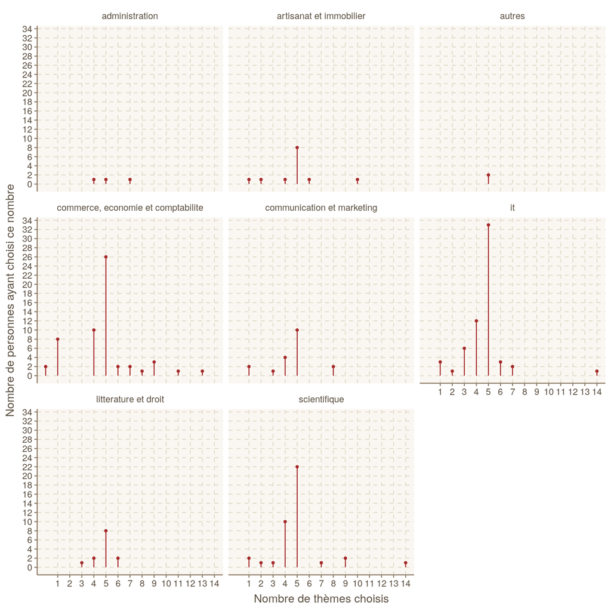

```r
new_dt %>%
  count(wrks_rec, nb_thm) %>%
  filt(!is.na(wrks_rec)) %>%
  ggplot() +
  geom_segment(aes(x = nb_thm, y = 0, xend = nb_thm, yend = n), colour = "brown") +
  geom_point(aes(x = nb_thm, y = n), size = 1, color = "brown")+
  facet_wrap(~wrks_rec, nrow = 3, ncol = 3)+
  scale_x_continuous(breaks = seq(0:14))+
  scale_y_continuous(breaks = seq(0, 40, by = 2)) +
  labs(y = "Nombre de personnes ayant choisi ce nombre", x = "Nombre de thèmes choisis")
```

### Les Thèmes choisis

Cette section étudie les thèmes choisis et les présente. On commence par se focaliser sur un pourcentage de 100 qui montre pour chaque thème, la proportion des personnes l’ayant choisi. Le graphe suivant illustre le résultat.

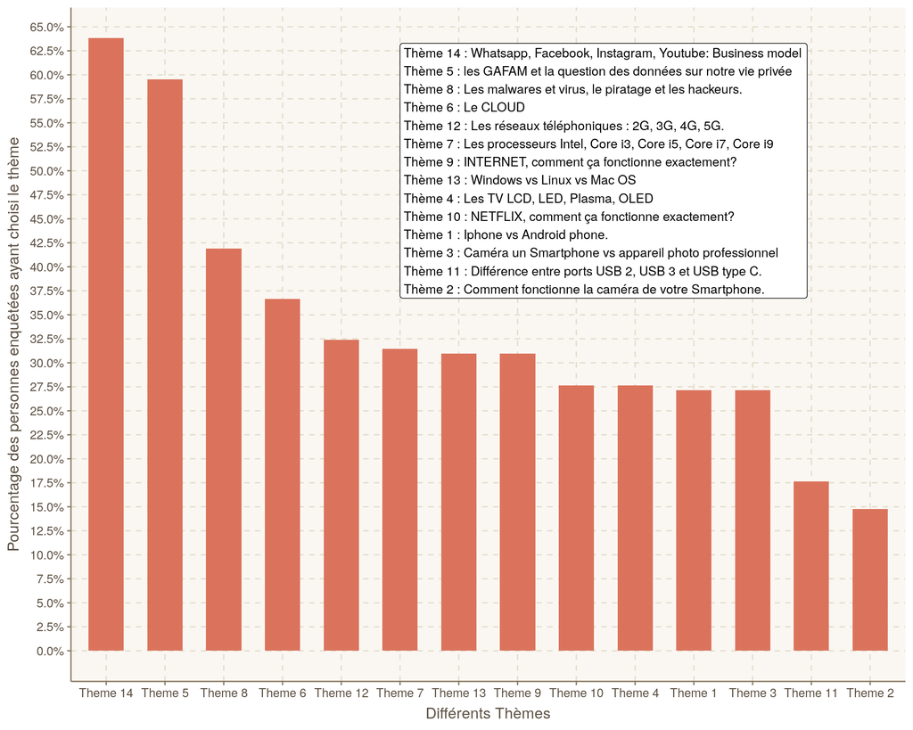

```r
# graphing the themes:
main_thm <- comp.thmprop(new_dt, thm1:thm14)

nthmlbl <- paste(themes_names[order(-main_thm$perc)], collapse = "\n")

main_thm %>%
  ggplot(aes(x = reorder(themes, -perc))) +
  geom_bar(aes(y = perc), stat = "identity", width = 0.6)+
  labs(x = "Différents Thèmes",
       y = "Pourcentage des personnes enquêtées ayant choisi le thème")+
  scale_y_continuous(breaks = perbreaks, labels = percent)+
  annotate("label", x = 6, y= 0.5, label = nthmlbl, hjust = 0, size = 3.5)
```

Les 5 premiers thèmes les plus choisis sont les Theme 14, Theme 5, Theme 8, Theme 6, Theme 12 sans prendre en compte le nombre de thèmes choisi par les répondants. On vérifie si le constat est le même par secteur d’activité à travers le graphique suivant:

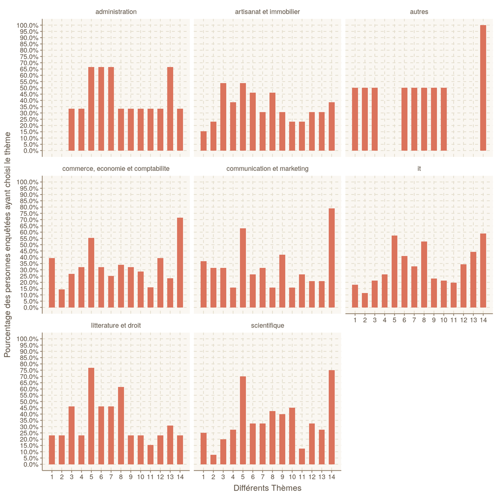

```r
# first I split my data
new_dt %>%
split( with(new_dt, wrks_rec))%>%
  map_dfr(function(x) comp.thmprop(x, thm1:thm14), .id = "wrks_rec") %>%
 ggplot(aes(x = gsub("Theme", "", themes) %>% as.numeric())) +
  geom_bar(aes(y = perc), stat = "identity", width = 0.6)+
  labs(x = "Différents Thèmes",
       y = "Pourcentage des personnes enquêtées ayant choisi le thème")+
  scale_y_continuous(breaks = seq(0, 1, by = 0.05), labels = percent)+
  scale_x_continuous(breaks = 1:14)+
  facet_wrap(~wrks_rec, nrow = 3, ncol = 3)
```

On peut maintenant se focaliser sur la même répartition, mais par groupe d’âge. On sera plus enclin à voir quels sont les thèmes fréquemment choisis par chaque groupe d’âge.

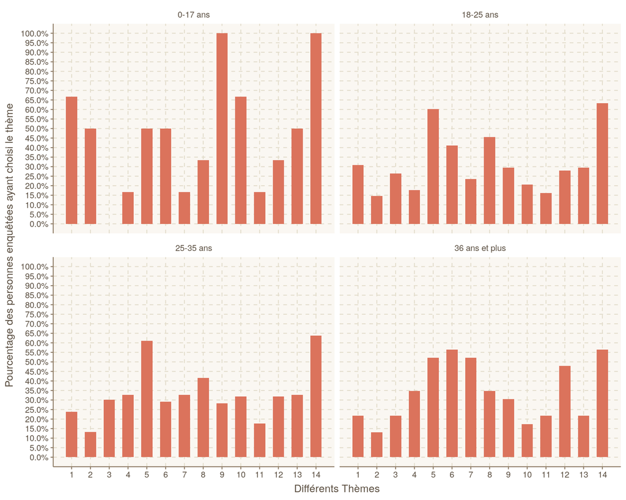

```r
new_dt %>%
split(with(new_dt, age))%>%
  map_dfr(function(x) comp.thmprop(x, thm1:thm14), .id = "wrks_rec") %>%
 ggplot(aes(x = gsub("Theme", "", themes) %>% as.numeric())) +
  geom_bar(aes(y = perc), stat = "identity", width = 0.6)+
  labs(x = "Différents Thèmes",
       y = "Pourcentage des personnes enquêtées ayant choisi le thème")+
  scale_y_continuous(breaks = seq(0, 1, by = 0.05), labels = percent)+
  scale_x_continuous(breaks = 1:14)+
  facet_wrap(~wrks_rec, ncol = 2)
```

Et pour finir, on effectue la même chose par sexe (On verra si les femmes aiment l’argent). Je ne rentre pas en profondeur dans les commentaires, parce que je ne sais pas comment les données se comporteront par la suite.

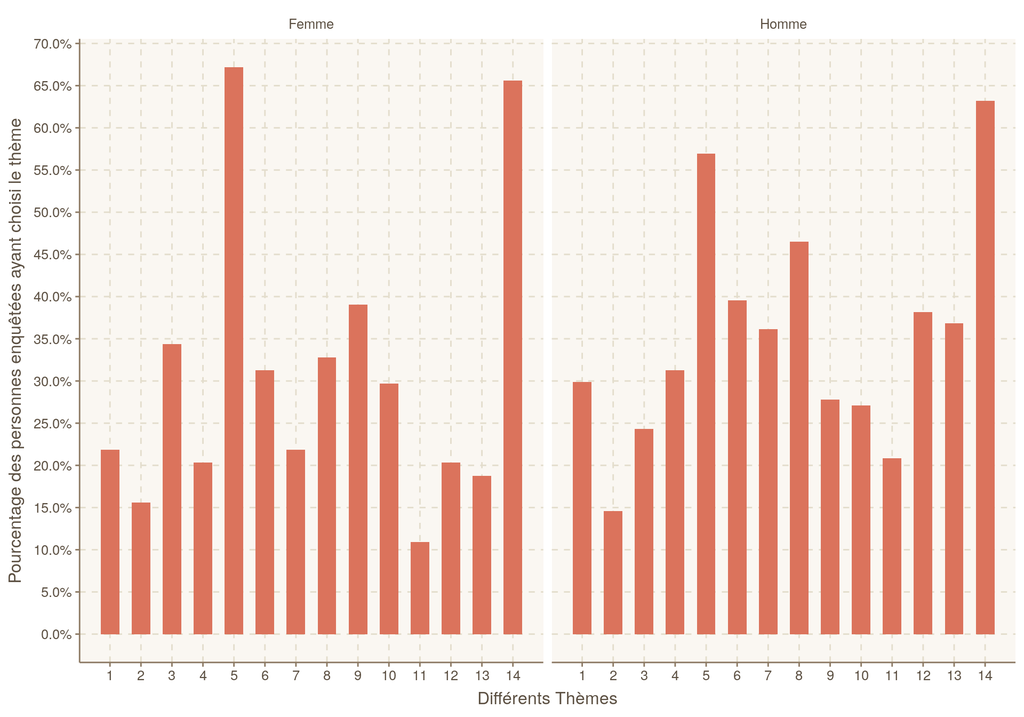

```r
new_dt %>%
split(with(new_dt, sex))%>%
  map_dfr(function(x) comp.thmprop(x, thm1:thm14), .id = "wrks_rec") %>%
 ggplot(aes(x = gsub("Theme", "", themes) %>% as.numeric())) +
  geom_bar(aes(y = perc), stat = "identity", width = 0.6)+
  labs(x = "Différents Thèmes",
       y = "Pourcentage des personnes enquêtées ayant choisi le thème")+
  scale_y_continuous(breaks = seq(0, 1, by = 0.05), labels = percent)+
  scale_x_continuous(breaks = 1:14)+
  facet_wrap(~wrks_rec, ncol = 2)
```

Nous avons dans les analyses précédentes considéré que le nombre de personnes ayant choisi un thème. Cette fois ci, nous allons nous appuyer sur une pondération que nous avons créé pour examiner les préférences, en rangeant suivant les différentes modalités du secteur d’activité, du groupe d’âge, et du sexe.

Commençons d’abord par une représentation globale:

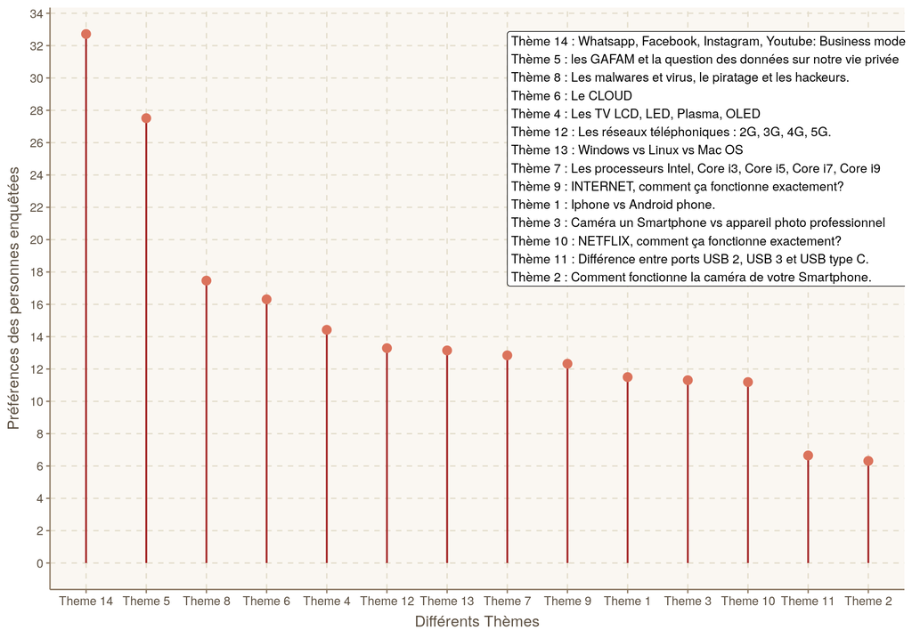

```r
pref_thm <- comp.thmpref(new_dt, thm1:thm14)
nthmlbl <- paste(themes_names[order(-pref_thm$wgt)], collapse = "\n")

ggplot(pref_thm, aes(x = reorder(themes, -wgt))) +
  geom_segment(aes(yend = wgt, xend = reorder(themes, -wgt), y=0), size = 0.7,
               colour = "brown") +
  geom_point(aes(y = wgt), size = 3)+
  labs(x = "Différents Thèmes", y = "Préférences des personnes enquêtées")+
  scale_y_continuous(breaks = seq(0, 50, by = 2))+
  annotate("label", x = 8, y= 25, label = nthmlbl, hjust = 0, size = 3.5)
```

Les préférences pour les secteurs d’activité:

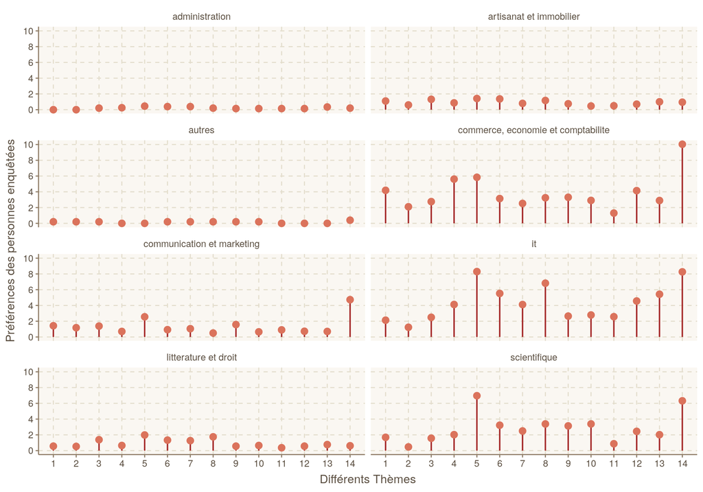

```r
new_dt %>%
split(with(new_dt, wrks_rec))%>%
  map_dfr(function(x) comp.thmpref(x, thm1:thm14), .id = "wrks_rec") %>%
  mutate(themes = gsub("Theme", "", themes) %>% as.numeric() ) %>%
  ggplot(aes(x =  themes)) +
  geom_segment(aes(yend = wgt, xend =  themes, y=0), size = 0.7,
               colour = "brown") +
  geom_point(aes(y = wgt), size = 3)+
  labs(x = "Différents Thèmes", y = "Préférences des personnes enquêtées")+
  scale_y_continuous(breaks = seq(0, 50, by = 2))+
  scale_x_continuous(breaks = 1:14)+
  facet_wrap(~wrks_rec, ncol = 2)
```

Les préférences pour les groupe d’âge

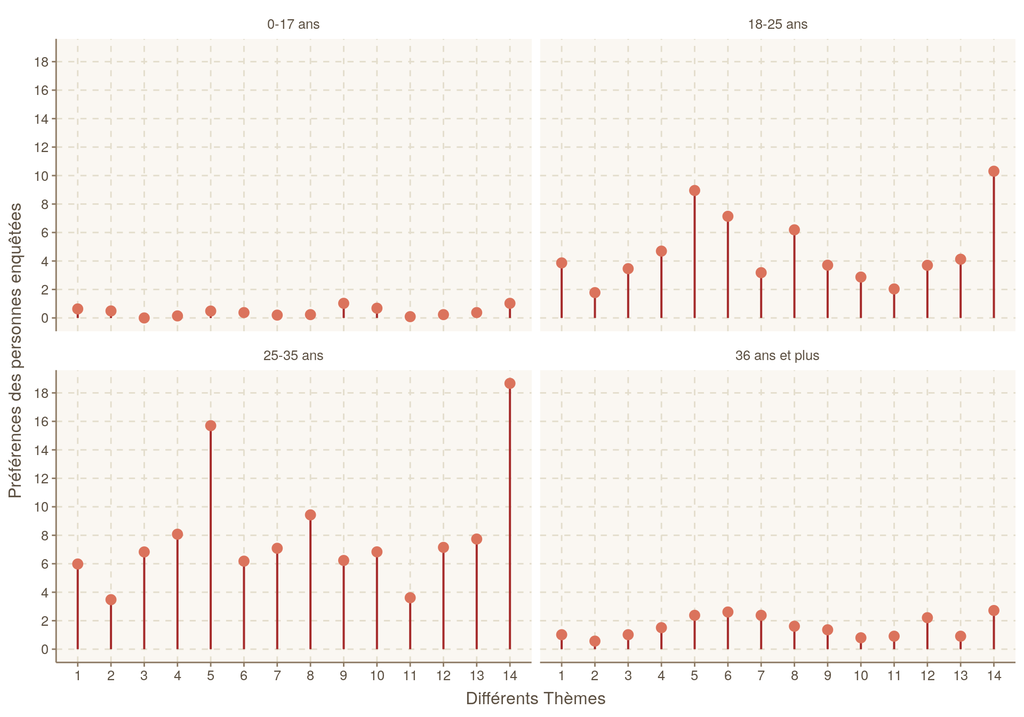

```r
new_dt %>%
split(with(new_dt, age))%>%
  map_dfr(function(x) comp.thmpref(x, thm1:thm14), .id = "wrks_rec") %>%
  mutate(themes = gsub("Theme", "", themes) %>% as.numeric() ) %>%
  ggplot(aes(x =  themes)) +
  geom_segment(aes(yend = wgt, xend =  themes, y=0), size = 0.7,
               colour = "brown") +
  geom_point(aes(y = wgt), size = 3)+
  labs(x = "Différents Thèmes", y = "Préférences des personnes enquêtées")+
  scale_y_continuous(breaks = seq(0, 50, by = 2))+
  scale_x_continuous(breaks = 1:14)+
  facet_wrap(~wrks_rec, ncol = 2)
```

Et enfin les préférences par sexe:

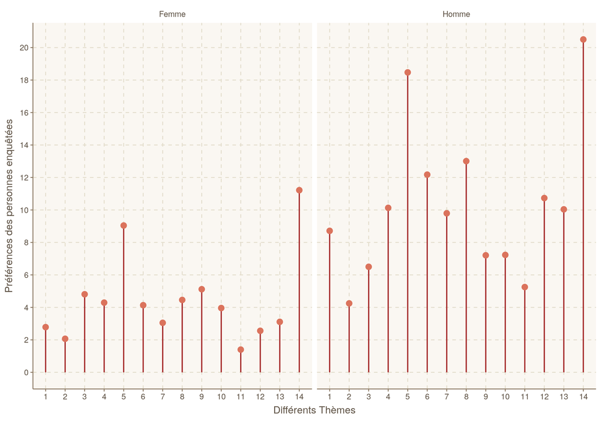

```r
new_dt %>%
split(with(new_dt, sex))%>%
  map_dfr(function(x) comp.thmpref(x, thm1:thm14), .id = "wrks_rec") %>%
  mutate(themes = gsub("Theme", "", themes) %>% as.numeric() ) %>%
  ggplot(aes(x =  themes)) +
  geom_segment(aes(yend = wgt, xend =  themes, y=0), size = 0.7,
               colour = "brown") +
  geom_point(aes(y = wgt), size = 3)+
  labs(x = "Différents Thèmes", y = "Préférences des personnes enquêtées")+
  scale_y_continuous(breaks = seq(0, 50, by = 2))+
  scale_x_continuous(breaks = 1:14)+
  facet_wrap(~wrks_rec, ncol = 2)
```

### Les tests

On a remarqué que à part les 4 premiers thèmes et les 2 derniers thèmes, les thèmes se trouvant au milieu, ont des préférences relativement très proches. Puisque nous disposons de la distribution de ces thèmes, nous allons tester si les préférences sont égales, ou si la différence que nous observons n’est pas statistiquement significative.

Nous passons pour celà à un test de kruskall wallis sur les thèmes “du milieu”. Il faut d’abord les identifier et ensuite torturer un peu la base de données.

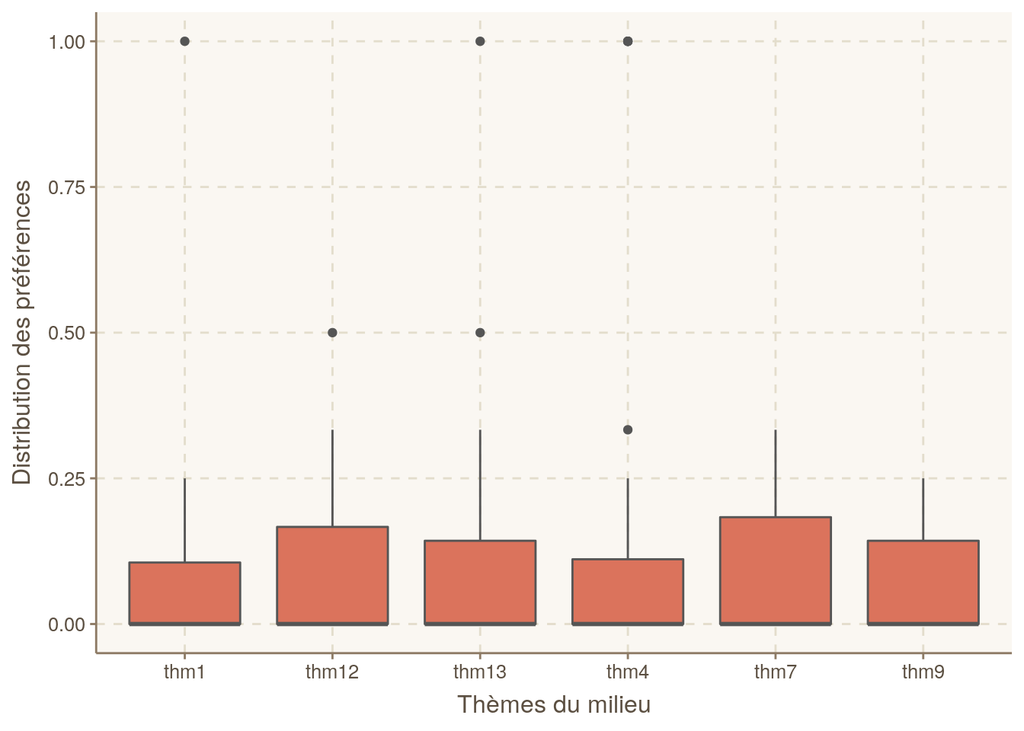

```r
inter_thm <- pref_thm %>%
  arrange(desc(wgt)) %>%
  #four first out and four last out
  with(themes[5:10])

inter_thm <- gsub("[A-z]|\\s", "", inter_thm)
inter_thm <- paste("thm", inter_thm, sep = "")

# weighted thm data
wgt_thm <- new_dt %>%
 selt(thm1:thm14) %>%
 apply(1, function(x) x / sum(x, na.rm = TRUE)) %>%
 t() %>%
 as.data.frame()

#selecting the themes for a kruskall wallis test.
thm_dt <- wgt_thm %>%
 as.data.frame() %>%
 selt(all_of(inter_thm)) %>%
 gather(key = "themes", value = "wgt")

#we start with a graphical view

ggplot(thm_dt %>% filt(!is.nan(wgt)), aes(x = themes, y = wgt)) +
  geom_boxplot()+
  labs(x = "Thèmes du milieu", y = "Distribution des préférences")
```

```r
#On effectue maintenant le test
test_data <- kruskal.test(themes ~ wgt, data = thm_dt)

if(test_data$p.value > 0.1){
  cat("Les préférences des thèmes du milieu sont statistiquement égales")
} else{
  cat("Les préférences des thèmes du milieu sont statistiquement différentesy")
}
```

```
## Les préférences des thèmes du milieu sont statistiquement égales
```

## Un peu plus loin

Cette partie va un peu plus en profondeur dans l’analyse. On peut regarder comment les préférences des thèmes sont réparties, et décider si oui ou non certains thèmes sont plus proches (eu égard les individus qui les ont choisi).

### Analyses en composantes

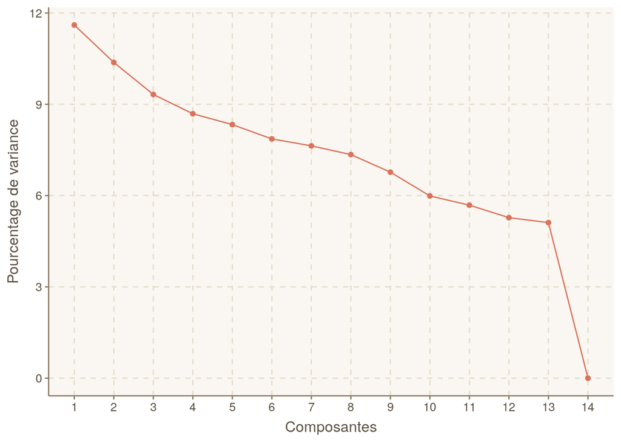

```r
library(FactoMineR)

pca_dt <- wgt_thm %>%
  bind_cols(new_dt %>% selt(age, wrks)) %>%
  filt(!is.na(thm1) & !is.na(wrks))

acp <- PCA(pca_dt, graph = FALSE, ncp = 8, quali.sup = c(15, 16))
eig <- acp$eig

colnames(eig) <- c("eig", "perc", "cum")
eig <- as.data.frame(eig)
eig$comp <- 1:14

#graphing eigen values
ggplot(eig, aes(x = comp, y = perc))+
  geom_point()+
  geom_line()+
  scale_x_continuous(breaks = 1:14)+
  labs(x = "Composantes", y = "Pourcentage de variance")
```

Vue le caractère très sparse de la matrice, il aurait mieux fallu faire un acp sur des données sparses. Mais je ne veux pas rentrer dans ces considérations. On peut se limiter au choix 8 premières composantes. Elles représentent environ 71.17% des variations dans les données (beaucoup de composantes, je sais). On va commencer par effectuer une rotation de la matrice des coordonnées des variables pour effectuer une interprétation. L’examen du cercle de corrélation est inutile, puisque les variables ne seraient pas assez bien représentées sur les deux premières composantes.

```r
rot_var <- varimax(acp$var$coord)

rot_var$loadings
```

```
##
## Loadings:
##       Dim.1  Dim.2  Dim.3  Dim.4  Dim.5  Dim.6  Dim.7  Dim.8
## thm1                        0.833
## thm2  -0.168                0.128  0.803                0.138
## thm3   0.192 -0.132        -0.342  0.585        -0.262 -0.189
## thm4   0.285 -0.679        -0.128 -0.182 -0.281 -0.217
## thm5  -0.256        -0.834 -0.112 -0.159                0.164
## thm6                 0.106               -0.104  0.118 -0.891
## thm7   0.549         0.156  0.289 -0.101 -0.319         0.156
## thm8   0.162  0.673 -0.138 -0.307 -0.218 -0.154  0.103
## thm9  -0.795                0.155        -0.127
## thm10         0.553  0.202                      -0.506  0.205
## thm11  0.146 -0.184  0.297 -0.312                0.415  0.447
## thm12 -0.327         0.616 -0.222 -0.297        -0.138  0.134
## thm13         0.179                      -0.125  0.797
## thm14                                     0.968 -0.112  0.108
##
##                Dim.1 Dim.2 Dim.3 Dim.4 Dim.5 Dim.6 Dim.7 Dim.8
## SS loadings    1.306 1.317 1.263 1.216 1.216 1.210 1.248 1.188
## Proportion Var 0.093 0.094 0.090 0.087 0.087 0.086 0.089 0.085
## Cumulative Var 0.093 0.187 0.278 0.364 0.451 0.538 0.627 0.712
```

On peut regarder les loadings sur les rotations et effectuer quelques commentaires. Les individus ayant préféré les thèmes 9, n’ont en général pas choisi les thèmes 7 et 4. D’un autre coté, les individus qui ont préféré le thème 10 ont en général préféré aussi le thème 10. Les thèmes 2 et 3 sont relativement proches en termes de préférences des individus.. Bon peut explorer la matrice pour regarder les thèmes ayant les poids élevés et de même signe sur chacune des dimensions. Puisque la base va changer à l’avenir, je ne rentre pas complètement dans les interprétations.

### La base finale

Il y a la base de données nettoyée, enregistrée au format xlsx.

```r
wb <- createWorkbook()
labs <- c("mails des répondants",
            "score",
            "thèmes",
            "autres thèmes",
            "Secteur d'activité",
            "Sexe",
            "Groupe d'âge",
            "Pays",
            paste("A choisi le thème", 1:14),
            "Secteur d'activité nettoyé",
            "Nombre de thèmes choisi")
label_dt <- data.frame(variables = colnames(new_dt), labels = labs)
addWorksheet(wb, "base_nettoyee")
addWorksheet(wb, "label_variables")

writeData(wb, sheet = "base_nettoyee", new_dt)
writeData(wb, sheet = "label_variables", x = "Label des variables de la base")
writeData(wb, sheet = "label_variables", label_dt, startRow = 3)

saveWorkbook(wb, file = "base_finale.xlsx", overwrite = TRUE)

# I also have an R version of the data
rbase <- list(data = new_dt, labels_data = label_dt)

# probably you will need the mails of respondants
# I promised to give the analysis to some of my group as a motivation fo fill
# the questionnaire. Mails are registred in mail_list.txt
# For whatsapp numbers, I let you deal with that.
#sink("mail_list.txt", append = FALSE)
cat(paste(new_dt$mail, collapse = ", "))
```

[output not shown]

```r
#sink()
```